# Lab 07

Adam Guerra

2022-11-8

#### Step #1: Set global options and load packages.

#### Step #2: Import water data; Clean data.

This data for this lab is from the [United States Geological Survey](https://water.usgs.gov/watuse/data/) for years 1950 - 2015.

Table 1: “Sets” of data, for which each of the sets have ALL column tags in common. Data from USGS (1950-2015).

| year | public supply | irrigation | rural | industrial | thermo | state |
| --- | --- | --- | --- | --- | --- | --- |
| 1950-1955 | ps_wgw_fr + ps_wsw_fr | ir_wgw_fr + ir_wsw_fr | NA | inpt_wgw_fr + inpt_wsw_fr | NA | area |
| 1960-80 | ps_wgw_fr + ps_wsw_fr | ir_wgw_fr + ir_wsw_fr | do_wgw_fr + do_wsw_fr + ls_wgw_fr + ls_wsw_fr | oi_wgw_fr + oi_wsw_fr | pt_wgw_fr + pt_wsw_fr | area |
| 1985-90 | ps_wgwfr + ps_wswfr | ir_wgwfr + ir_wswfr | do_ssgwf + do_ssswf + ls_gwtot + ls_swtot | in_wgwfr + in_wswfr + mi_wgwfr + mi_wswfr | pt_wgwfr + pt_wswfr | scode |
| 1995 | ps_wgw_fr + ps_wsw_fr | ir_wgw_fr + ir_wsw_fr | do_wgw_fr + do_wsw_fr + ls_wgw_fr + ls_wsw_fr | in_wgw_fr + in_wsw_fr + mi_wgw_fr + mi_wsw_fr | pt_wgw_fr + pt_wsw_fr | state_code |
| 2000 | ps_wgw_fr + ps_wsw_fr | it_wgw_fr + it_wsw_fr | do_wgw_fr + do_wsw_fr + ls_wgw_fr + ls_wsw_fr | in_wgw_fr + in_wsw_fr + mi_wgw_fr + mi_wsw_fr | pt_wgw_fr + pt_wsw_fr | statefips |
| 2005 | ps_wgw_fr + ps_wsw_fr | ir_wgw_fr + ir_wsw_fr | do_wgw_fr + do_wsw_fr + ls_wgw_fr + ls_wsw_fr | in_wgw_fr + in_wsw_fr + mi_wgw_fr + mi_wsw_fr | pt_wgw_fr + pt_wsw_fr | statefips |
| 2010-15 | ps_wgw_fr + ps_wsw_fr | ir_wgw_fr + ir_wsw_fr | do_wgw_fr + do_wsw_fr + li_wgw_fr + li_wsw_fr | in_wgw_fr + in_wsw_fr + mi_wgw_fr + mi_wsw_fr | pt_wgw_fr + pt_wsw_fr | statefips |

#### Step 3: Organize data by sector.

```r
#create water use 1950
wu_1950 <- d_1950 |>
           mutate(state = area,
                  public_supply = ps_wgw_fr + ps_wsw_fr,
                  irrigation = ir_wgw_fr + ir_wsw_fr,
                  rural = NA,
                  industrial = inpt_wgw_fr + inpt_wsw_fr,
                  thermoelectric = NA,
                  year = 1950) |>
           select(state, public_supply, irrigation, rural, industrial,
                  thermoelectric, year) |>
           pivot_longer(2:6, names_to = "Sector",
                        values_to = "Withdrawals")

#create water use 1955
wu_1955 <- d_1955 |>
           mutate(state = area,
                  public_supply = ps_wgw_fr + ps_wsw_fr,
                  irrigation = ir_wgw_fr + ir_wsw_fr,
                  rural = NA,
                  industrial = inpt_wgw_fr + inpt_wsw_fr,
                  thermoelectric = NA,
                  year = 1955) |>
           select(state, public_supply, irrigation, rural, industrial,
                  thermoelectric, year) |>
           pivot_longer(2:6, names_to = "Sector",
                        values_to = "Withdrawals")

#create water use 1960
wu_1960 <- d_1960 |>
           mutate(state = area,
                  public_supply = ps_wgw_fr + ps_wsw_fr,
                  #irrigation = ir=wgw_fr + ir_wsw_fr does not work because data is missing these values
                  irrigation = ir_w_fr_to,
                  rural = do_wgw_fr + do_wsw_fr + ls_wgw_fr + ls_wsw_fr,
                  industrial = oi_wgw_fr + oi_wsw_fr,
                  thermoelectric = pt_wgw_fr + pt_wsw_fr,
                  year = 1960) |>
           select(state, public_supply, irrigation, rural, industrial,
                  thermoelectric, year) |>
           pivot_longer(2:6, names_to = "Sector",
                        values_to = "Withdrawals")

#create water use 1965
wu_1965 <- d_1965 |>
           mutate(state = area,
                  public_supply = ps_wgw_fr + ps_wsw_fr,
                  irrigation = ir_wgw_fr + ir_wsw_fr,
                  rural = do_wgw_fr + do_wsw_fr + ls_wgw_fr + ls_wsw_fr,
                  industrial = oi_wgw_fr + oi_wsw_fr,
                  thermoelectric = pt_wgw_fr + pt_wsw_fr,
                  year = 1965) |>
           select(state, public_supply, irrigation, rural, industrial,
                  thermoelectric, year) |>
           pivot_longer(2:6, names_to = "Sector",
                        values_to = "Withdrawals")

#create water use 1970
wu_1970 <- d_1970 |>
           mutate(state = area,
                  public_supply = ps_wgw_fr + ps_wsw_fr,
                  irrigation = ir_wgw_fr + ir_wsw_fr,
                  rural = do_wgw_fr + do_wsw_fr + ls_wgw_fr + ls_wsw_fr,
                  industrial = oi_wgw_fr + oi_wsw_fr,
                  thermoelectric = pt_wgw_fr + pt_wsw_fr,
                  year = 1970) |>
           select(state, public_supply, irrigation, rural, industrial,
                  thermoelectric, year) |>
           pivot_longer(2:6, names_to = "Sector",
                        values_to = "Withdrawals")

#create water use 1975
wu_1975 <- d_1975 |>
           mutate(state = area,
                  public_supply = ps_wgw_fr + ps_wsw_fr,
                  irrigation = ir_wgw_fr + ir_wsw_fr,
                  rural = do_wgw_fr + do_wsw_fr + ls_wgw_fr + ls_wsw_fr,
                  industrial = oi_wgw_fr + oi_wsw_fr,
                  thermoelectric = pt_wgw_fr + pt_wsw_fr,
                  year = 1975) |>
           select(state, public_supply, irrigation, rural, industrial,
                  thermoelectric, year) |>
           pivot_longer(2:6, names_to = "Sector",
                        values_to = "Withdrawals")

#create water use 1980
wu_1980 <- d_1980 |>
           mutate(state = area,
                  public_supply = ps_wgw_fr + ps_wsw_fr,
                  irrigation = ir_wgw_fr + ir_wsw_fr,
                  rural = do_wgw_fr + do_wsw_fr + ls_wgw_fr + ls_wsw_fr,
                  industrial = oi_wgw_fr + oi_wsw_fr,
                  thermoelectric = pt_wgw_fr + pt_wsw_fr,
                  year = 1980) |>
           select(state, public_supply, irrigation, rural, industrial,
                  thermoelectric, year) |>
           pivot_longer(2:6, names_to = "Sector",
                        values_to = "Withdrawals")

#create water use 1985
wu_1985 <- d_1985 |>
           mutate(state = scode,
                  public_supply = ps_wgwfr + ps_wswfr,
                  irrigation = ir_wgwfr + ir_wswfr,
                  rural = do_ssgwf + do_ssswf + ls_gwtot + ls_swtot,
                  industrial = in_wgwfr + in_wswfr + mi_wgwfr + mi_wswfr,
                  thermoelectric = pt_wgwfr + pt_wswfr,
                  year = 1985) |>
           select(state, public_supply, irrigation, rural, industrial,
                  thermoelectric, year) |>
           group_by(state, year) |>
           summarize_at(1:5, sum, na.rm = TRUE) |>
           ungroup() |>
           pivot_longer(3:7, names_to = "Sector",
                        values_to = "Withdrawals")

#create water use 1990
wu_1990 <- d_1990 |>
           mutate(state = scode,
                  public_supply = ps_wgwfr + ps_wswfr,
                  irrigation = ir_wgwfr + ir_wswfr,
                  rural = do_ssgwf + do_ssswf + ls_gwtot + ls_swtot,
                  industrial = in_wgwfr + in_wswfr + mi_wgwfr + mi_wswfr,
                  thermoelectric = pt_wgwfr + pt_wswfr,
                  year = 1990) |>
           select(state, public_supply, irrigation, rural, industrial,
                  thermoelectric, year) |>
           group_by(state, year) |>
           summarize_at(1:5, sum, na.rm = TRUE) |>
           ungroup() |>
           pivot_longer(3:7, names_to = "Sector",
                        values_to = "Withdrawals")

#create water use 1995
wu_1995 <- d_1995 |>
           mutate(state = state_code,
                  public_supply = ps_wgw_fr + ps_wsw_fr,
                  irrigation = ir_wgw_fr + ir_wsw_fr,
                  rural = do_wgw_fr + do_wsw_fr + ls_wgw_fr + ls_wsw_fr,
                  industrial = in_wgw_fr + in_wsw_fr + mi_wgw_fr + mi_wsw_fr,
                  thermoelectric = pt_wgw_fr + pt_wsw_fr,
                  year = 1995) |>
           select(state, public_supply, irrigation, rural, industrial,
                  thermoelectric, year) |>
           group_by(state, year) |>
           summarize_at(1:5, sum, na.rm = TRUE) |>
           ungroup() |>
           pivot_longer(3:7, names_to = "Sector",
                        values_to = "Withdrawals")

#create water use 2000
wu_2000 <- d_2000 |>
           mutate(state = statefips,
                  public_supply = ps_wgw_fr + ps_wsw_fr,
                  irrigation = it_wgw_fr + it_wsw_fr,
                  rural = do_wgw_fr + do_wsw_fr + ls_wgw_fr + ls_wsw_fr,
                  industrial = in_wgw_fr + in_wsw_fr + mi_wgw_fr + mi_wsw_fr,
                  thermoelectric = pt_wgw_fr + pt_wsw_fr,
                  year = 2000) |>
           select(state, public_supply, irrigation, rural, industrial,
                  thermoelectric, year) |>
           group_by(state, year) |>
           summarize_at(1:5, sum, na.rm = TRUE) |>
           ungroup() |>
           pivot_longer(3:7, names_to = "Sector",
                        values_to = "Withdrawals")

#create water use 2005
wu_2005 <- d_2005 |>
           mutate(state = statefips,
                  public_supply = ps_wgw_fr + ps_wsw_fr,
                  irrigation = ir_wgw_fr + ir_wsw_fr,
                  rural = do_wgw_fr + do_wsw_fr + ls_wgw_fr + ls_wsw_fr,
                  industrial = in_wgw_fr + in_wsw_fr + mi_wgw_fr + mi_wsw_fr,
                  thermoelectric = pt_wgw_fr + pt_wsw_fr,
                  year = 2005) |>
           select(state, public_supply, irrigation, rural, industrial,
                  thermoelectric, year) |>
           group_by(state, year) |>
           summarize_at(1:5, sum, na.rm = TRUE) |>
           ungroup() |>
           pivot_longer(3:7, names_to = "Sector",
                        values_to = "Withdrawals")

#create water use 2005
wu_2010 <- d_2010 |>
           mutate(state = statefips,
                  public_supply = ps_wgw_fr + ps_wsw_fr,
                  irrigation = ir_wgw_fr + ir_wsw_fr,
                  rural = do_wgw_fr + do_wsw_fr + li_wgw_fr + li_wsw_fr,
                  industrial = in_wgw_fr + in_wsw_fr + mi_wgw_fr + mi_wsw_fr,
                  thermoelectric = pt_wgw_fr + pt_wsw_fr,
                  year = 2010) |>
           select(state, public_supply, irrigation, rural, industrial,
                  thermoelectric, year) |>
           group_by(state, year) |>
           summarize_at(1:5, sum, na.rm = TRUE) |>
           ungroup() |>
           pivot_longer(3:7, names_to = "Sector",
                        values_to = "Withdrawals")

#create water use 2015
wu_2015 <- d_2015 |>
           mutate(state = statefips,
                  public_supply = ps_wgw_fr + ps_wsw_fr,
                  irrigation = ir_wgw_fr + ir_wsw_fr,
                  rural = do_wgw_fr + do_wsw_fr + li_wgw_fr + li_wsw_fr,
                  industrial = in_wgw_fr + in_wsw_fr + mi_wgw_fr + mi_wsw_fr,
                  thermoelectric = pt_wgw_fr + pt_wsw_fr,
                  year = 2015) |>
           select(state, public_supply, irrigation, rural, industrial,
                  thermoelectric, year) |>
           group_by(state, year) |>
           summarize_at(1:5, sum, na.rm = TRUE) |>
           ungroup() |>
           pivot_longer(3:7, names_to = "Sector",
                        values_to = "Withdrawals")
```

#### Step 4: organize and combine data for plotting.

```r
#create object with all data frames combined
wu_all <- rbind(wu_1950, wu_1955, wu_1960, wu_1965, wu_1970, wu_1975, wu_1980,
                wu_1985, wu_1990, wu_1995, wu_2000, wu_2005, wu_2010,
                wu_2015) |>
          filter(!state %in% c("11", "72", "78"))

#create object with totals by year
wu_all_total <- wu_all |>
                group_by(year) |>
                summarize_at(3, sum, na.rm = TRUE) |>
                ungroup()

#create object with totals by year and sector
wu_all_sector <- wu_all |>
                 group_by(Sector, year) |>
                 summarize_at(2, sum, na.rm = TRUE) |>
                 ungroup()

#create object to check totals
wu_all_check <- wu_all |>
                group_by(Sector) |>
                summarize_at(3, sum, na.rm = TRUE) |>
                ungroup() |>
                arrange(-Withdrawals)
```

#### Step 5: Setup plot for timeseries of sector withdrawals.

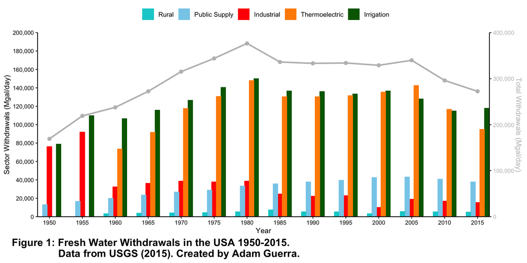

```r
ggplot() +                                                                      #create ggplot
  geom_col(data = wu_all_sector,                                                #column plot select data
           aes(x = year, y = Withdrawals, fill = reorder(Sector, Withdrawals)), #set axis/fill values
           position = position_dodge(3.5), width = 4) +                         #adjust position/width
           scale_fill_manual(values = c("Dark Turquoise", "Sky Blue", "Red",    #set colors for columns
                                       "Dark Orange", "Dark Green"),
                             labels = c("Rural", "Public Supply", "Industrial", #change legend labels
                                   "Thermoelectric", "Irrigation")) +
           guides(fill = guide_legend(title = "")) +                            #remove legend title
  geom_line(data = wu_all_total,                                                #line plot data select
            aes(x = year, y = Withdrawals / 2),                                 #set axis for line
            size = 1, color = "grey",                                           #set size and color of line
            show.legend = FALSE) +                                              #remove line legend
  geom_point(data = wu_all_total,                                               #point plot select data
             aes(x = year, y = Withdrawals /2),                                 #set point axis
             size = 2,                                                          #set point size
             color = "grey",                                                    #set point color
             show.legend = FALSE) +                                             #remove point plot legend
  scale_x_continuous(breaks = scales::pretty_breaks(n = 14),                    #set x scale
                     expand = c(0,0)) +                                         #start x at origin
  scale_y_continuous(breaks = scales::pretty_breaks(n = 14),                    #set y scale
                     labels = scales::comma,                                    #make y values comma sep
                     limits = c(0,200000),                                      #set left y axis limits
                     name = "Sector Withdrawals (Mgal/day)",                    #set left y axis name
                     sec.axis = sec_axis(trans = ~.*2,                          #create right y axis
                                         name = "Total Withdrawals (Mgal/day)", #set right y axis name
                                         labels = scales::comma),               #make right y comma sep
                     expand = c(0,0)) +                                         #start y at origin
  labs(x = "Year",                                                              #set x axis name
       caption = "Figure 1: Fresh Water Withdrawals in the USA 1950-2015.
                Data from USGS (2015). Created by Adam Guerra.",
       fill = "") +                                                             #set caption name and fill
  ggplot2::theme_classic() +                                                    #good time series theme set
  theme(legend.position = "top",                                                #set legend position
        axis.text = element_text(size = 8, color = "black"),                    #set axis text color and size
        axis.title = element_text(size = 10),                                   #set axis title size
        axis.text.y.right = element_text(color = "grey"),                       #set y axis right text color
        axis.title.y.right = element_text(color = "grey"),                      #set y axis right title color
        plot.caption = element_text(size = 14, face = "bold",                   #set plot caption title size/bold
                                    hjust = -0.15))                             #set height on plot caption
```

**Q2: What is most surprising outcome of Figure 1?**  
The most surprising outcome of Figure 1 is that public supply did not have as dramatic of an increase as other sectors.

**Q3: Go to the USGS plot that shows withdrawals by sector (scroll down, the relevant plot is at the bottom); the bars in the USGS plot show different patterns than our plot. How is the plot different and why?**  
There plot has sectors broken into slightly different groupings than ours, also both of their y-axis have different units than ours. They could have also used other sources to fill in data gaps we may potentially have.